# MATH7340_Clustering_PCA

Yaochieh Yao

3/31/2023

## Module 10 – Clustering

**Problem 1 Clustering analysis on the “CCND3 Cyclin D3” gene expression values of the Golub et al. (1999) data.**  
a.Conduct hierarchical clustering using single linkage and Ward linkage. Plot the cluster dendrogram for both fit. Get two clusters from each of the methods. Use function table() to compare the clusters with the two patient groups ALL/AML. Which linkage function seems to work better here?  
ANS:  
The Ward linkage generally works better; its cluster 1 basic include only ALL patient with 21 samples. In contrast, the Single linkage hardly separates ALL and AML patient in cluster 1, and in its cluster 2 only have 1 AML patient sample, which shows the clustering result is not well.

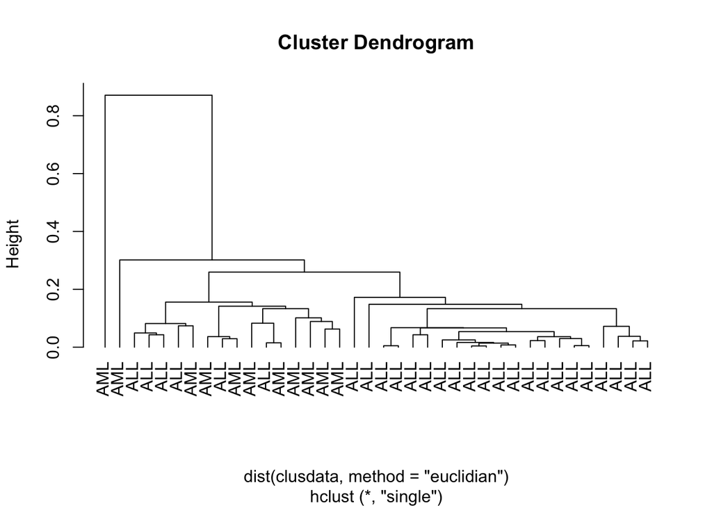

```r
clusdata <- data.frame(golub[1042,])
gol.fac <- factor(golub.cl,levels=0:1, labels= c("ALL","AML"))
# Conduct hierarchical clustering using single and Ward linkage
hc_sing<-hclust(dist(clusdata,method="euclidian"),method="single")
hc_ward<-hclust(dist(clusdata,method="euclidian"),method="ward.D2")
# Plot the cluster dendrogram for both fit
plot(hc_sing,hang=-1,labels=gol.fac)
```

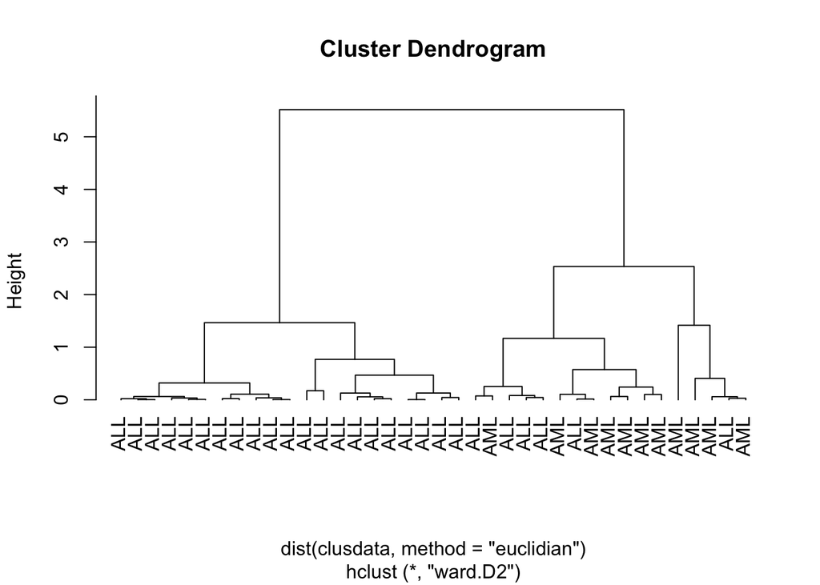

```r
plot(hc_ward,hang=-1,labels=gol.fac)
```

```r
# Get two clusters from each of the methods
gp_sing<-cutree(hc_sing,k=2)
gp_ward<-cutree(hc_ward,k=2)
# Use function table() to compare the clusters with the
# two patient groups ALL/AML
t(table(gp_sing,gol.fac))
```

```
##        gp_sing
## gol.fac  1  2
##     ALL 27  0
##     AML 10  1
```

```r
t(table(gp_ward,gol.fac))
```

```
##        gp_ward
## gol.fac  1  2
##     ALL 21  6
##     AML  0 11
```

b.Use k-means cluster analysis to get two clusters. Use table() to compare the two clusters with the two patient groups ALL/AML.

```r
# problem 1-b
# Use k-means cluster analysis to get two clusters
km<-kmeans(clusdata,centers=2)
km_clus<-km$cluster
# Use table() to compare the two clusters with the
# two patient groups ALL/AML
t(table(km_clus,gol.fac))
```

```
##        km_clus
## gol.fac  1  2
##     ALL 22  5
##     AML  1 10
```

c.Which clustering approach (hierarchical versus k-means) produce the best matches to the two diagnose groups ALL/AML?  
ANS:  
The Ward linkage hierarchical clustering and k-means clustering both have a good separation for ALL patients in cluster 1 and a near differentiation for AML patients in cluster 2 and have the same amount of misclassification. However, if we compare the noise, Ward linkage hierarchical clustering is the best because in its cluster 1 is perfect separation with no other noise from AML.

```r
# problem 1-d
# Find the two cluster means from the k-means cluster analysis
initial<-km$centers
km$tot.withinss
```

```
## [1] 6.497036
```

```r
# Perform a bootstrap on the cluster means
n <- dim(clusdata)[1]; nboot<-1000
boot.cl <- matrix(NA,nrow=nboot,ncol = 2)
for (i in 1:nboot){
  # Sample with replacement from the data
  sample_idx <- sample(1:n, replace = TRUE)
  sample_data <- clusdata[sample_idx, ]
  # Perform k-means clustering with two clusters on the resampled data
  cl <- kmeans(sample_data, initial, nstart = 10)
  # Save two means to boostrap cluster matrix
  boot.cl[i,] <- c(cl$centers[1,],cl$centers[2,])
}
apply(boot.cl,2,mean)
```

```
## [1] 2.0304864 0.6957767
```

```r
# Do the confidence intervals for the cluster means
quantile(boot.cl[,1],c(0.025,0.975))
```

```
##     2.5%    97.5%
## 1.847373 2.196109
```

```r
quantile(boot.cl[,2],c(0.025,0.975))
```

```
##      2.5%     97.5%
## 0.2095286 1.0583935
```

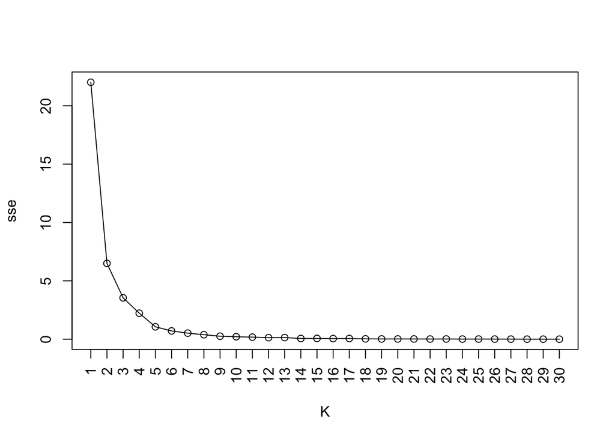

```r
# problem 1-e
# Produce a plot of K versus SSE, for K=1, …, 30
K<-(1:30); sse<-rep(NA,length(K))
for (k in K) { sse[k]<-kmeans(clusdata, centers=k,nstart = 10)$tot.withinss
}
plot(K, sse, type='o', xaxt='n'); axis(1, at = K, las=2)
```

**Problem 2: Cluster analysis on part of Golub data.**  
a.Select the oncogenes and antigens from the Golub data.

```r
# problem 2-a
# (a) Select the oncogenes and antigens from the Golub data
sel1 <- grep("oncogene|Oncogene|ONCOGENE",golub.gnames[,2])
sel2 <- grep("antigen|Antigen|ANTIGEN",golub.gnames[,2])
selected_genes <- rbind(golub[sel1,],golub[sel2,])
g.name<-rep(c("oncogene","antigen"),c(length(sel1),length(sel2)))
```

b.On the selected data, do clustering analysis for the genes (not for the patients). Using K-means and K-medoids with K=2 to cluster the genes. Use table() to compare the resulting two clusters with the two gene groups oncogenes and antigens for each of the two clustering analysis.

```r
# problem 2-b
# (b) Using K-means and K-medoids with K=2 to cluster the genes. Use table() to
# compare the resulting two clusters with the two gene groups oncogenes and
# antigens for each of the two clustering analysis
kmeans_clusters <- kmeans(selected_genes, centers = 2)
kmedoids_clusters <- pam(selected_genes, k = 2)
table_kmeans <- t(table(kmeans_clusters$cluster, g.name))
table_kmeans
```

```
##
## g.name      1  2
##   antigen  44 50
##   oncogene 20 27
```

```r
table_kmedoids <- t(table(kmedoids_clusters$clustering, g.name))
table_kmedoids
```

```
##
## g.name      1  2
##   antigen  57 37
##   oncogene 32 15
```

```r
# problem 2-c
# (c)   Use appropriate tests (from previous modules) to test the marginal
# independence in the two by two tables in (b). Which clustering method provides
# clusters related to the two gene groups?
chi2_kmeans <- chisq.test(table_kmeans)
chi2_kmedoids <- chisq.test(table_kmedoids)
chi2_kmedoids
```

```
##
##  Pearson's Chi-squared test with Yates' continuity correction
##
## data:  table_kmedoids
## X-squared = 0.46081, df = 1, p-value = 0.4972
```

```r
chi2_kmeans
```

```
##
##  Pearson's Chi-squared test with Yates' continuity correction
##
## data:  table_kmeans
## X-squared = 0.089413, df = 1, p-value = 0.7649
```

d.Plot the cluster dendrograms for this part of golub data with single linkage and complete linkage, using Euclidean distance.

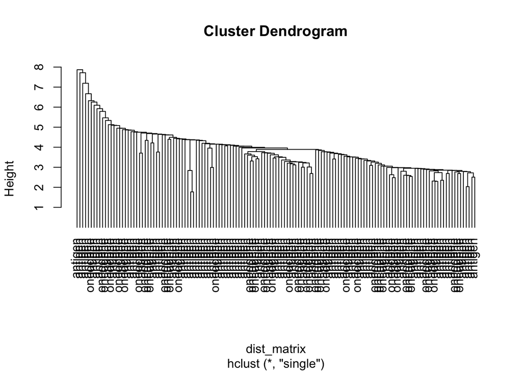

```r
# (d) Plot the cluster dendrograms for this part of golub data with single
# linkage and complete linkage, using Euclidean distance.
dist_matrix <- dist(selected_genes, method = "euclidean")
plot(hclust(dist_matrix,method="single") ,hang = -1, labels=g.name)
```

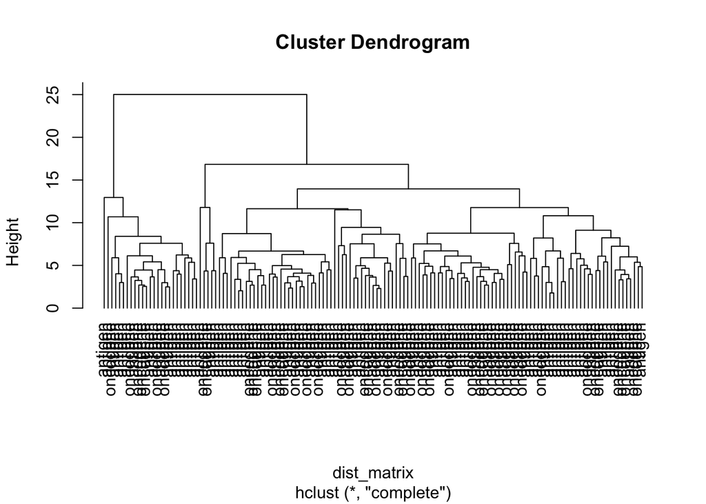

```r
plot(hclust(dist_matrix,method="complete"),hang = -1, labels=g.name)
```

## Module 11 – PCA

**Problem 1 Analysis of the ALL data set**  
For the following parts, we define an indicator variable ALL.fac such that ALL.fac=1 for T-cell patients and ALL.fac=2 for B-cell patients.  
You may use your own names for these but for uniformity, I would prefer using these same names. library(ALL); data(ALL) expr.ALL<-exprs(ALL) ALL.fac <- as.numeric(ALL$BT %in% c(“B”,“B1”,“B2”,“B3”,“B4”))+1

a.Plot the histograms for the first three genes’ expression values in one row.

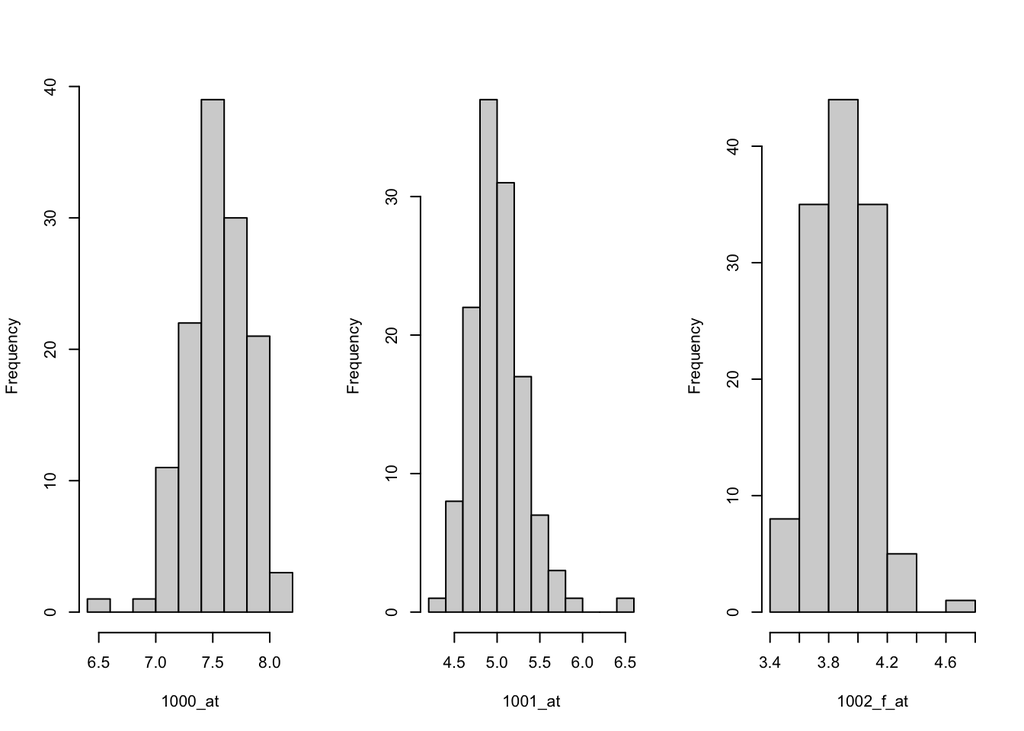

```r
# problem 1-a
expr_ALL<-exprs(ALL)
ALL_fac <- as.numeric(ALL$BT %in% c("B","B1","B2","B3","B4"))+1
par(mfrow=c(1,3))
for (i in 1:3) {
  hist(expr_ALL[i,],xlab=rownames(expr_ALL)[i],main=NULL)
}
```

b.Plot the pairwise scatterplots for the first five genes.

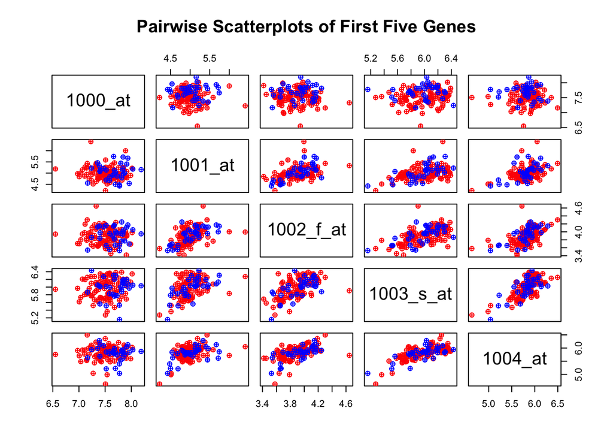

```r
# problem 1-b
F5G<-t(data.frame(expr_ALL[1:5,]))
pairs(F5G,main="Pairwise Scatterplots of First Five Genes",
      pch=10, col=ifelse(ALL_fac==1, "blue", "red"))
```

```r
# problem 1-d
X<-cbind(X1,X2,X3)
K2<-kmeans(X, centers = 2)
K3<-kmeans(X, centers = 3)
table(ALL_fac, K2$cluster)
```

```
##
## ALL_fac  1  2
##       1 29  4
##       2 10 85
```

```r
table(ALL_fac, K3$cluster)
```

```
##
## ALL_fac  1  2  3
##       1  3 28  2
##       2 70  5 20
```

e.Carry out the PCA on the ALL data set with scaled variables. What proportion of variance is explained by the first principal component? By the second principal component?  
ANS:  
This table shows that the first principal component (PC1) explains 93.59% of the total variance in the data, while the second principal component (PC2) explains about 0.95% of the variance. Therefore, the first two principal components combined explain 94.54% of the total variance.

```r
# problem 1-e
scaled_ALL<- scale(expr_ALL)
pca_ALL <- prcomp(scaled_ALL)
summary(pca_ALL)$importance[,1:2]
```

```
##                             PC1      PC2
## Standard deviation     10.94498 1.101323
## Proportion of Variance  0.93588 0.009480
## Cumulative Proportion   0.93588 0.945360
```

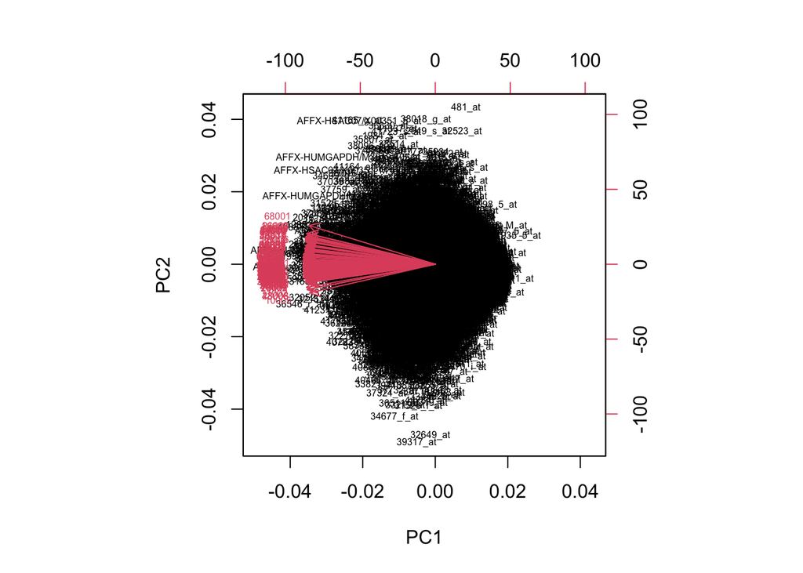

```r
# problem 1-f
biplot(pca_ALL, cex=0.5)
```

g.For the second principal component PC2, print out the three genes with biggest loadings and the three genes with smallest loadings.

```r
# problem 1-g
PC2<-pca_ALL$rotation[,2]
largest_PC2 <- order(PC2, decreasing = TRUE)[1:3]
smallest_PC2 <- order(PC2)[1:3]
# The biggest loading genes of PC2
featureNames(ALL)[largest_PC2]
```

```
## [1] "1083_s_at" "1044_s_at" "1025_g_at"
```

```r
# The smallest loading genes of PC2
featureNames(ALL)[smallest_PC2]
```

```
## [1] "1091_at"   "1109_s_at" "1105_s_at"
```

**Problem 2 Variables scaling and PCA in the iris data set**  
In this module and last module, we mentioned that the variables are often scaled before doing the PCA or the clustering analysis. By “scaling a variable”, we mean to apply a linear transformation to center the observations to have mean zero and standard deviation one. In last module, we also mentioned using the correlation-based dissimilarity measure versus using the Euclidean distance in clustering analysis. It turns out that the correlation-based dissimilarity measure is proportional to the squared Euclidean distance on the scaled variables. We check this on the iris data set. And we compare the PCA on scaled versus unscaled variables for the iris data set.

a.Create a data set consisting of the first four numerical variables in the iris data set (That is, to drop the last variable Species which is categorical). Then make a scaled data set that centers each of the four variables (columns) to have mean zero and variance one.

```r
# problem 2-a
rm(list=ls())
data(iris)
iris2<-data.frame(iris[,-5])
iris_scale <- apply(iris2,2,function(x) scale(x))
```

b.Calculate the correlations between the columns of the data sets using the cor()function. Show that these correlations are the same for scaled and the unscaled data sets.  
ANS:  
We can see from the two tables below are the same since scaling does not change the correlations between variables, which means it only scales them to have a mean of 0 and a variance of 1.

```r
# problem 2-b
# Unscaled
cor(iris2)
```

```
##              Sepal.Length Sepal.Width Petal.Length Petal.Width
## Sepal.Length    1.0000000  -0.1175698    0.8717538   0.8179411
## Sepal.Width    -0.1175698   1.0000000   -0.4284401  -0.3661259
## Petal.Length    0.8717538  -0.4284401    1.0000000   0.9628654
## Petal.Width     0.8179411  -0.3661259    0.9628654   1.0000000
```

```r
# Scaled
cor(iris_scale)
```

```
##              Sepal.Length Sepal.Width Petal.Length Petal.Width
## Sepal.Length    1.0000000  -0.1175698    0.8717538   0.8179411
## Sepal.Width    -0.1175698   1.0000000   -0.4284401  -0.3661259
## Petal.Length    0.8717538  -0.4284401    1.0000000   0.9628654
## Petal.Width     0.8179411  -0.3661259    0.9628654   1.0000000
```

c.Show the outputs for doing PCA on the scaled data set and on the unscaled data set.(Apply PCA on the two data sets with option “scale=FALSE”. Do NOT use option “scale=TRUE”, which will scale data no matter which data set you are using.) Are they the same?  
ANS:  
No, they are not the same, because the scaled data set has been centered and scaled, while the unscaled data set has not.

```r
# problem 2-c
# Unscaled
unscaled_pca <- prcomp(iris2,scale=FALSE)
summary(unscaled_pca)
```

```
## Importance of components:
##                           PC1     PC2    PC3     PC4
## Standard deviation     2.0563 0.49262 0.2797 0.15439
## Proportion of Variance 0.9246 0.05307 0.0171 0.00521
## Cumulative Proportion  0.9246 0.97769 0.9948 1.00000
```

```r
# Scaled
scaled_pca <- prcomp(iris_scale,scale=FALSE)
summary(scaled_pca)
```

```
## Importance of components:
##                           PC1    PC2     PC3     PC4
## Standard deviation     1.7084 0.9560 0.38309 0.14393
## Proportion of Variance 0.7296 0.2285 0.03669 0.00518
## Cumulative Proportion  0.7296 0.9581 0.99482 1.00000
```

d.What proportions of variance are explained by the first two principal components in the scaled PCA and in the unscaled PCA?

ANS:  
According to the table of (c), we can get the proportion as followed:  
Unscaled proportion of variance:  
PC1: 92.46%  
PC2: 5.31%  
Scaled proportion of variance:  
PC1: 72.96%  
PC2: 22.85%

e.Find a 90% confidence interval on the proportion of variance explained by the second principal component, in the scaled PCA.

```r
# problem 2-e
data <- data.frame(scaled_pca$x[,2]);p <- ncol(data); n <- nrow(data);nboot<-1000
sdevs <- array(dim=c(nboot,p)) #matrix to save resampled sdev for p PC2
for (i in 1:nboot) {
  dat.star <- data[sample(1:n,replace=TRUE),] #resample rows
  sdevs[i,] <- sum(prcomp(dat.star)$sdev^2)/sum(scaled_pca$sdev^2)
  # proportion of variance (sd^2)
}
print(quantile(sdevs[,1], c(0.05,0.950)),digits = 4)
```

```
##     5%    95%
## 0.1809 0.2762
```